# Practical Machine Learning Course Report

Pablo Adames

October 25, 2015

# Summary

Generate a model to predict the type of dumbell biceps curl executed by the subjects in the **Weight Lifting Exercises Dataset** following the classification given by expert trainers.

# Load data

Data source: http://groupware.les.inf.puc-rio.br/har

```r
# read the data for the project as training and test groups
trndat<-read.csv(file="data/pml-training.csv")
tstdat<-read.csv(file="data/pml-testing.csv")
```

```
## [1] "'trndat' data set: 19622 observations on 159 predictors."
```

```
## [1] "'tstdat' data set: 20 observations on 159 predictors."
```

# Cleaning data set

A first inspection showed there were many columns with non-numeric values. Discarding those columns removed 36 variables. The `knnImpute` could not be used on this data set because of the sensitivity of the time series.

```
## [1] "'trainSet' data set with 19622 observations on 123 predictors."
```

The predictors with remaining `NA`s were eliminated using the custom function `extractColumnsWithTooManyNAs` as shown in the code shown in Appendix A.

```
## [1] "'trainClean' data set with 19622 observations on 56 variables."
```

```
## [1] "'testClean' data set with 20 observations on 56 variables."
```

# Exploratory analysys

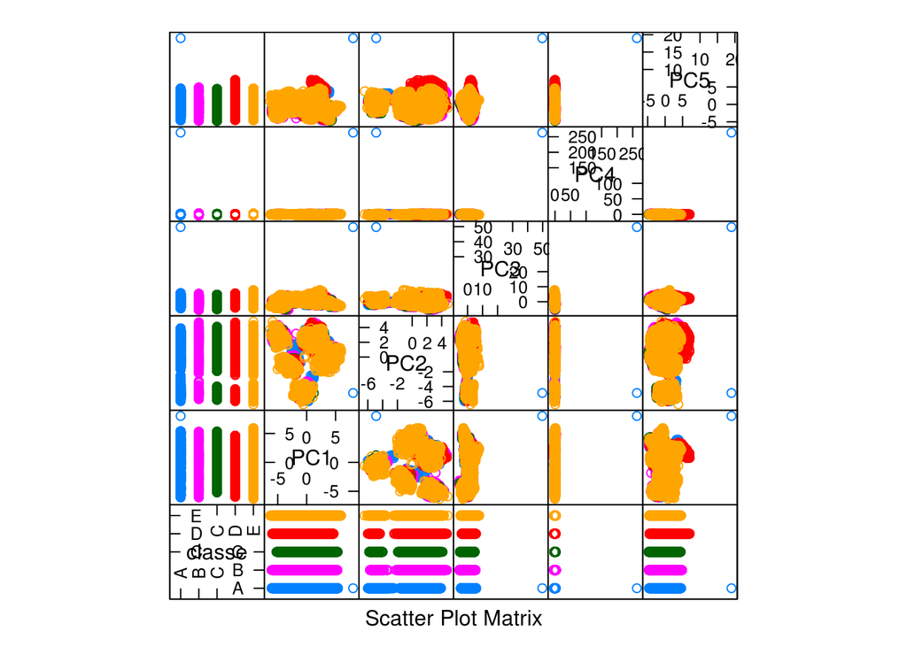

```r
preproc <- preProcess(trainClean[-1],method = "pca",pcaComp = 5)
dumbbellPC <- predict(preproc,trainClean[-1])
featurePlot(x=dumbbellPC,y=trainClean$classe,plot="pairs")
```

# Generating a predictive model

The non-linear behaviour observed in the principal component analysis motivated a random forest algorithm to be used for predicting the type of the dumbbell bicep curl. In view of the long time to fit a random forest model to this data set, parallel processing was necessary.

```r
library(doParallel)
cl<-makeCluster(6)
registerDoParallel(cl)
require(randomForest)
```

```
rf_model_full <- train(classe~.,data=trainClean,
                  method="rf",
                  trControl=trainControl(method="cv",number=5),
                  prox=TRUE,
                  allowParallel=TRUE)
rf_model_full
Random Forest

19622 samples
   56 predictors
    5 classes: 'A', 'B', 'C', 'D', 'E'

No pre-processing
Resampling: Cross-Validated (5 fold)
Summary of sample sizes: 15698, 15698, 15698, 15697, 15697
Resampling results across tuning parameters:

  mtry  Accuracy   Kappa      Accuracy SD   Kappa SD
   2    0.9988788  0.9985818  0.0004966670  0.0006282220
  29    0.9998981  0.9998711  0.0001395827  0.0001765530
  56    0.9997961  0.9997421  0.0002132122  0.0002696789

Accuracy was used to select the optimal model using  the largest value.
The final value used for the model was mtry = 29.
```

Since the accuracy looks very high this model will be used to predict the test samples.

```
answers <- predict(rf_model_full,newdata = testClean)
```

# Appendix A. Code for cleaning the original data set

```
library(caret)
# get the column class
column_class <- function( col ){ifelse(is.data.frame(col), class(col[[1]]), class(col))}
extractNumericCols <- function( df ) {
  # get the column names to index inot the data frame
  l_col_names <- names(df)
  # nullify the columns with non-numeric values, return list of data.frames
  l <- sapply(l_col_names,
              function(x) { cls <- column_class( df[x] );
              ifelse(cls %in% c("numeric","integer"), df[x], "NULL")})
  # filter the columns where there are only numeric values
  isNULL <- which(l[names(l)] =="NULL"); ll <- l[-isNULL]
  # compose a data frame with the numeric columns (data.frames)
  ndf <- do.call(cbind.data.frame,ll)
}
# new data frame with only numeric columns:
trainSet <- extractNumericCols(trndat)
# add outcome column as column #1:
trainSet$classe <- trndat$classe
# filter the numeric columns in the test set
numericColNames <- colnames(trainSet)
testSet <- tstdat[,which(colnames(tstdat) %in% numericColNames)]
print(paste0("'trainSet' data set with ",dim(trainSet)[1], " observations", " on ", dim(trainSet)[2]-1, " predictors."))

extractColumnsWithTooManyNAs <- function( df){
  l <- sapply(colnames(df), function(x) any( is.na(df[x][[1]]) ) )
  df[-which(l)]
}
# eliminate all columns with NAs in them
trainClean <- extractColumnsWithTooManyNAs(trainSet)
testClean <- extractColumnsWithTooManyNAs(testSet)
print(paste0("'trainClean' data set with ",dim(trainClean)[1], " observations", " on ", dim(trainClean)[2]-1, " variables."))
print(paste0("'testClean' data set with ", dim(testClean)[1], " observations on ", dim(testClean)[2], " variables."))
```